# 4470 Final Project: Life Expectancy data

April 24th, 2019

## Overview

This is our final project for MIS 4470. For this project we chose to do data analysis on countries around the world to find out about life expectancy based on 18 variables (15 continuous variables were used). The data used in this project was taken mostly from the World Health Organization and also UNICEF.

The purpose of this project was to use what we learned this semester to do some productive EDA and linear regressions to find out which variables were most important in relation to life expectancy at birth (LEB).

## Read in data

A complete data dictionary is included in the README file. For the purpose of this project, we shortened/abbreviated many of the variable names.

```r
pp <- read.csv(file = "data/ProjectDataComplete.csv", header = TRUE, sep = ",")
```

## Load libraries

```r
library(ggplot2)
library(corrplot)
library(dplyr)
library(tidyr)
library(corrplot)
library(caret)
library(MLmetrics)
library(gbm)
```

## Look into dataframe

At first glance, it made sense to change year into a factor. Other than counts of years, we did not need more descriptive statistics about the variable.

We also included some code to omit the one NA under Health Expenditure per Capita (HE_CAP).

```r
# preview of data
pp$Year <- as.factor(pp$Year)
str(pp)
```

```
## 'data.frame':    1836 obs. of  18 variables:
##  $ Country: Factor w/ 108 levels "Albania","Algeria",..: 1 1 1 1 1 1 1 1 1 1 ...
##  $ Region : Factor w/ 15 levels "Caribbean","Central Africa",..: 5 5 5 5 5 5 5 5 5 5 ...
##  $ Year   : Factor w/ 17 levels "2000","2001",..: 1 2 3 4 5 6 7 8 9 10 ...
##  $ HDI    : num  0.669 0.676 0.682 0.689 0.694 0.704 0.711 0.72 0.724 0.729 ...
##  $ NMR    : num  11 10.6 10.1 9.6 9.1 8.6 8.2 7.7 7.2 6.8 ...
##  $ IMR    : num  21.8 20.4 19.1 17.8 16.6 15.4 14.3 13.3 12.3 11.5 ...
##  $ U5MR   : num  24.5 22.9 21.4 19.9 18.5 17.2 16 14.8 13.8 12.8 ...
##  $ X5_14MR: num  3.7 3.6 3.5 3.5 3.4 3.3 3.2 3.1 3 2.9 ...
##  $ AMR    : int  106 100 102 107 101 106 101 101 102 103 ...
##  $ LEB    : num  73.1 74 73.5 72.9 73.3 73.5 73.9 74.1 74.2 74.4 ...
##  $ LE_60  : num  18.9 19.6 19.1 18.4 18.6 18.9 19 19.2 19.4 19.6 ...
##  $ UA     : num  2.3 2.2 2.1 2.1 2 1.9 1.8 1.8 1.7 1.6 ...
##  $ OA     : num  45 46 46.9 47.9 48.9 49.9 50.8 51.7 52.6 53.5 ...
##  $ OBA    : num  12.8 13.3 13.9 14.4 15 15.6 16.2 16.9 17.5 18.1 ...
##  $ avg_BMI: num  25.1 25.2 25.3 25.4 25.5 25.6 25.8 25.9 26 26.1 ...
##  $ ABS    : int  88 89 90 91 91 92 93 94 94 95 ...
##  $ HE_GDP : num  6.8 6.5 6.4 6.4 6.6 6.3 5.9 6.1 5.6 5.1 ...
##  $ HE_CAP : num  75.5 81.9 89.9 113.6 152 ...
```

```r
summary(pp)
```

```
##                 Country                Region         Year
##  Albania            :  17   Eastern Europe:357   2000   : 108
##  Algeria            :  17   Western Europe:323   2001   : 108
##  Andorra            :  17   Caribbean     :204   2002   : 108
##  Antigua and Barbuda:  17   Middle East   :187   2003   : 108
##  Argentina          :  17   South America :170   2004   : 108
##  Armenia            :  17   East Asia     :136   2005   : 108
##  (Other)            :1734   (Other)       :459   (Other):1188
##       HDI              NMR              IMR             U5MR
##  Min.   :0.5650   Min.   : 0.900   Min.   : 1.70   Min.   : 2.20
##  1st Qu.:0.7170   1st Qu.: 3.100   1st Qu.: 4.60   1st Qu.: 5.50
##  Median :0.7720   Median : 5.900   Median : 9.60   Median :11.25
##  Mean   :0.7806   Mean   : 7.976   Mean   :12.53   Mean   :14.99
##  3rd Qu.:0.8492   3rd Qu.:10.700   3rd Qu.:16.52   3rd Qu.:19.23
##  Max.   :0.9480   Max.   :34.100   Max.   :65.50   Max.   :87.00
##
##     X5_14MR            AMR             LEB            LE_60
##  Min.   : 0.500   Min.   : 49.0   Min.   :47.60   Min.   :14.40
##  1st Qu.: 1.300   1st Qu.: 81.0   1st Qu.:72.60   1st Qu.:18.80
##  Median : 2.450   Median :116.0   Median :75.00   Median :20.20
##  Mean   : 2.753   Mean   :127.5   Mean   :75.12   Mean   :20.58
##  3rd Qu.: 3.600   3rd Qu.:156.0   3rd Qu.:78.60   3rd Qu.:22.40
##  Max.   :18.400   Max.   :645.0   Max.   :84.20   Max.   :26.40
##
##        UA               OA             OBA          avg_BMI
##  Min.   : 0.400   Min.   :14.10   Min.   : 2.0   Min.   :21.50
##  1st Qu.: 1.300   1st Qu.:47.50   1st Qu.:16.2   1st Qu.:25.60
##  Median : 2.000   Median :55.70   Median :20.5   Median :26.40
##  Mean   : 3.197   Mean   :52.77   Mean   :20.4   Mean   :26.35
##  3rd Qu.: 4.225   3rd Qu.:60.50   3rd Qu.:24.3   3rd Qu.:27.10
##  Max.   :18.900   Max.   :84.40   Max.   :54.9   Max.   :31.90
##
##       ABS             HE_GDP           HE_CAP
##  Min.   : 39.00   Min.   : 1.600   Min.   :   16.0
##  1st Qu.: 87.00   1st Qu.: 4.900   1st Qu.:  244.8
##  Median : 95.00   Median : 6.300   Median :  533.4
##  Mean   : 91.58   Mean   : 6.717   Mean   : 1329.8
##  3rd Qu.: 99.00   3rd Qu.: 8.300   3rd Qu.: 1559.6
##  Max.   :100.00   Max.   :27.400   Max.   :10060.3
##                                    NA's   :1
```

```r
# omit NAs
pp <- na.omit(pp)
```

## Correlation analysis/EDA

Before we dove into correlation analysis, we wanted to standardize the data on a z-score. After the data was normalized, we constructed a visualization to more easily differentiate small and big correlations.

Once the correlations were visualized, a new dataframe was constructed without variables with high correlation. This would help with our regression models later in the analysis.

A new visualization of variables with low correlations was constructed.

```r
# Take out strings for correlations
#pp2 <- pp[setdiff(colnames(pp), c('Year', 'Country', 'Region'))]

# Standardize to z-scale
#pp2 <- scale(pp2)

# Make z-scaled data-frame from matrix (helps later in analysis)
# make a copy of the data frame
pp3 <- pp[setdiff(colnames(pp), c('Year', 'Country', 'Region'))]
# use scale() on those columns
scaledvars <- scale(pp3[, 1-15])
# use the matrix to write back to the data frame
pp3[, 1-15] <- scaledvars

# Correlation plots
cm <- cor(pp3)
round(cm,2)
```

```
##           HDI   NMR   IMR  U5MR X5_14MR   AMR   LEB LE_60    UA    OA
## HDI      1.00 -0.78 -0.77 -0.75   -0.66 -0.62  0.79  0.73 -0.46  0.33
## NMR     -0.78  1.00  0.97  0.95    0.73  0.59 -0.73 -0.55  0.41 -0.29
## IMR     -0.77  0.97  1.00  0.99    0.76  0.61 -0.77 -0.59  0.38 -0.27
## U5MR    -0.75  0.95  0.99  1.00    0.80  0.65 -0.78 -0.58  0.40 -0.28
## X5_14MR -0.66  0.73  0.76  0.80    1.00  0.60 -0.70 -0.51  0.46 -0.24
## AMR     -0.62  0.59  0.61  0.65    0.60  1.00 -0.91 -0.68  0.37 -0.29
## LEB      0.79 -0.73 -0.77 -0.78   -0.70 -0.91  1.00  0.88 -0.41  0.27
## LE_60    0.73 -0.55 -0.59 -0.58   -0.51 -0.68  0.88  1.00 -0.29  0.16
## UA      -0.46  0.41  0.38  0.40    0.46  0.37 -0.41 -0.29  1.00 -0.80
## OA       0.33 -0.29 -0.27 -0.28   -0.24 -0.29  0.27  0.16 -0.80  1.00
## OBA      0.20 -0.17 -0.16 -0.17   -0.08 -0.21  0.17  0.06 -0.67  0.88
## avg_BMI  0.18 -0.19 -0.18 -0.21   -0.15 -0.19  0.16  0.00 -0.64  0.75
## ABS      0.62 -0.66 -0.64 -0.68   -0.71 -0.56  0.60  0.39 -0.38  0.29
## HE_GDP   0.36 -0.22 -0.22 -0.21   -0.27 -0.35  0.42  0.43 -0.40  0.40
## HE_CAP   0.78 -0.49 -0.49 -0.46   -0.44 -0.48  0.63  0.68 -0.33  0.26
##           OBA avg_BMI   ABS HE_GDP HE_CAP
## HDI      0.20    0.18  0.62   0.36   0.78
## NMR     -0.17   -0.19 -0.66  -0.22  -0.49
## IMR     -0.16   -0.18 -0.64  -0.22  -0.49
## U5MR    -0.17   -0.21 -0.68  -0.21  -0.46
## X5_14MR -0.08   -0.15 -0.71  -0.27  -0.44
## AMR     -0.21   -0.19 -0.56  -0.35  -0.48
## LEB      0.17    0.16  0.60   0.42   0.63
## LE_60    0.06    0.00  0.39   0.43   0.68
## UA      -0.67   -0.64 -0.38  -0.40  -0.33
## OA       0.88    0.75  0.29   0.40   0.26
## OBA      1.00    0.85  0.25   0.38   0.16
## avg_BMI  0.85    1.00  0.29   0.22   0.10
## ABS      0.25    0.29  1.00   0.25   0.40
## HE_GDP   0.38    0.22  0.25   1.00   0.53
## HE_CAP   0.16    0.10  0.40   0.53   1.00
```

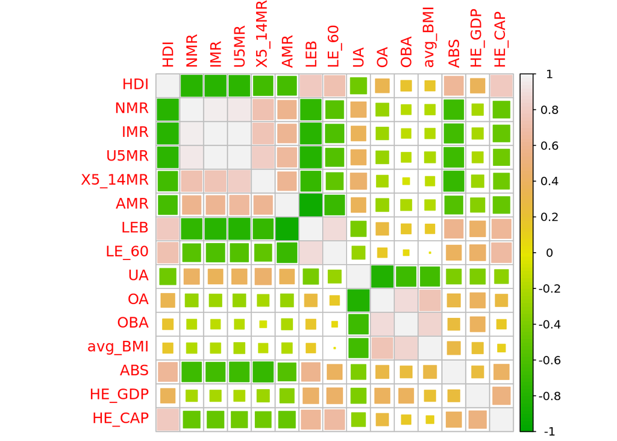

```r
corrplot(cm, method="square", col = terrain.colors(100))
```

```r
# Take out varibles with high correlation, to avoid multicollinearity
trimmed_pp <- cor(pp3)
trimmed <- findCorrelation(trimmed_pp, cutoff = 0.8)
trimmed <- sort(trimmed)
clean_df <- pp3[,-c(trimmed)]

# New corr plots
cm2 <- cor(clean_df)
round(cm2,2)
```

```
##           HDI   NMR X5_14MR   AMR LE_60    OA avg_BMI   ABS HE_GDP HE_CAP
## HDI      1.00 -0.78   -0.66 -0.62  0.73  0.33    0.18  0.62   0.36   0.78
## NMR     -0.78  1.00    0.73  0.59 -0.55 -0.29   -0.19 -0.66  -0.22  -0.49
## X5_14MR -0.66  0.73    1.00  0.60 -0.51 -0.24   -0.15 -0.71  -0.27  -0.44
## AMR     -0.62  0.59    0.60  1.00 -0.68 -0.29   -0.19 -0.56  -0.35  -0.48
## LE_60    0.73 -0.55   -0.51 -0.68  1.00  0.16    0.00  0.39   0.43   0.68
## OA       0.33 -0.29   -0.24 -0.29  0.16  1.00    0.75  0.29   0.40   0.26
## avg_BMI  0.18 -0.19   -0.15 -0.19  0.00  0.75    1.00  0.29   0.22   0.10
## ABS      0.62 -0.66   -0.71 -0.56  0.39  0.29    0.29  1.00   0.25   0.40
## HE_GDP   0.36 -0.22   -0.27 -0.35  0.43  0.40    0.22  0.25   1.00   0.53
## HE_CAP   0.78 -0.49   -0.44 -0.48  0.68  0.26    0.10  0.40   0.53   1.00
```

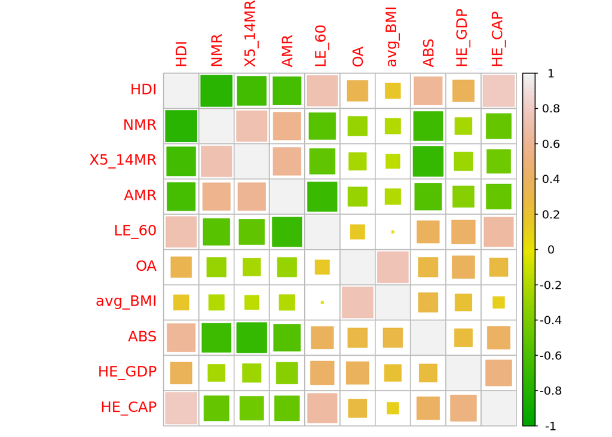

```r
corrplot(cm2, method="square", col = terrain.colors(100))
```

## More EDA

For further EDA, we chose to us the ggplot package to get more visualizations of the data.

Many attempts were made at trying to construct an animated scatter of HE_CAP, LEB and HDI (Human Development Index metric from WHO), but apparently we needed to download an older version of one of the packages from github. Our efforts were unsuccessful.

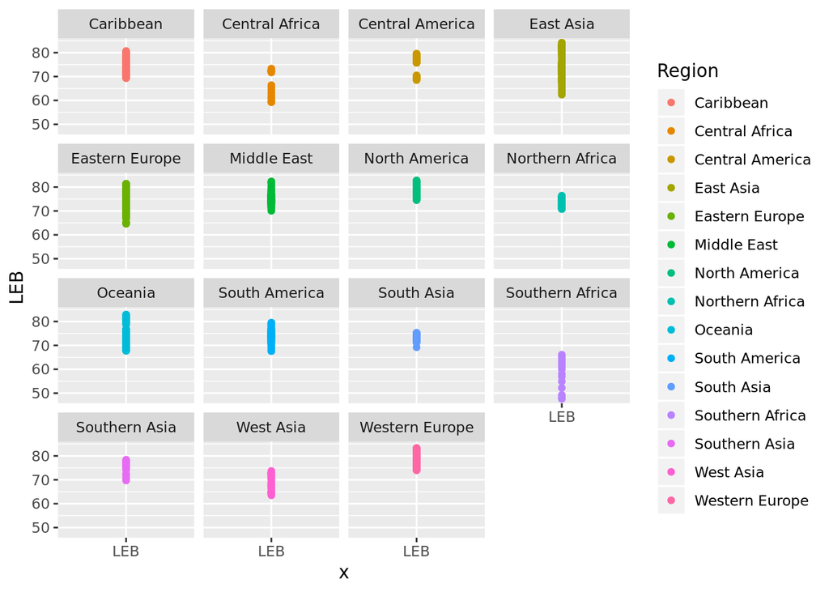

```r
# Unscaled dataframe for data visualizations
pp2 <- pp[setdiff(colnames(pp), c('Year', 'Country', 'Region'))]

#Set shortcut for ggplot
g <- ggplot(data=pp2)

#Faceted wrap of Life Expectancy
ggplot(data = pp, aes(x="LEB", y=LEB)) + geom_point(aes(group = Region, color = Region)) + facet_wrap(~Region)
```

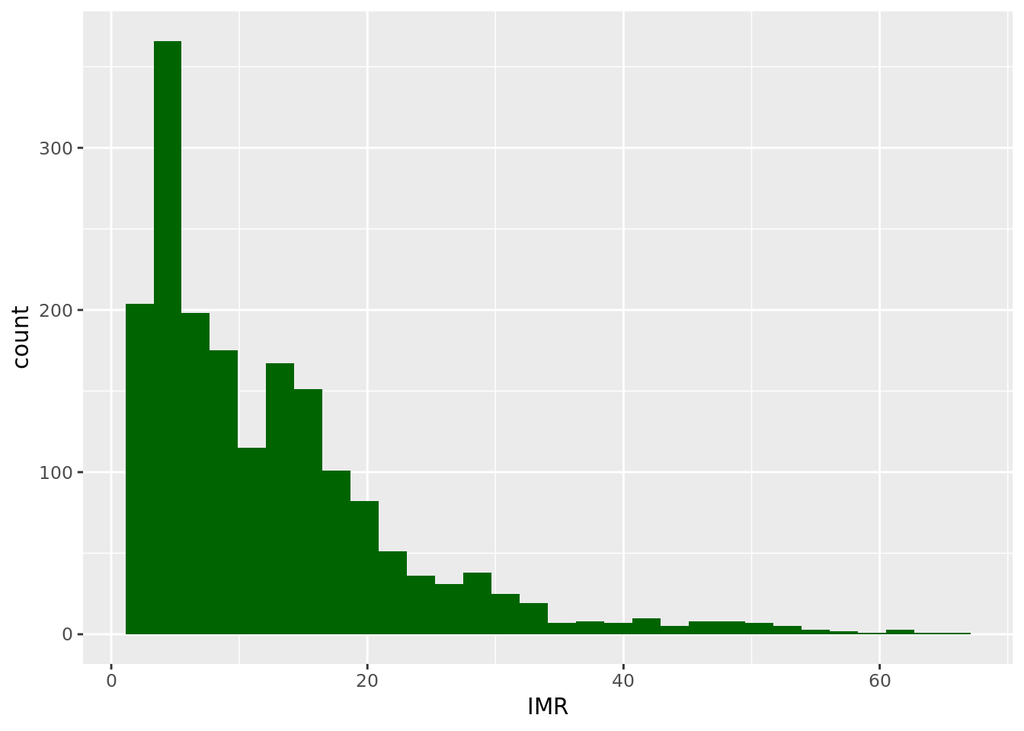

```r
#More plotssssss
g + geom_histogram(aes(x=IMR), fill="darkgreen")
```

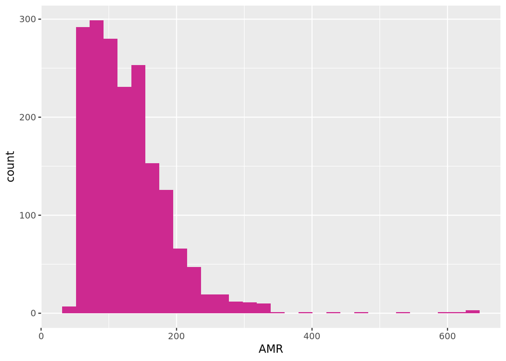

```r
g + geom_histogram(aes(x=AMR), fill="maroon3")
```

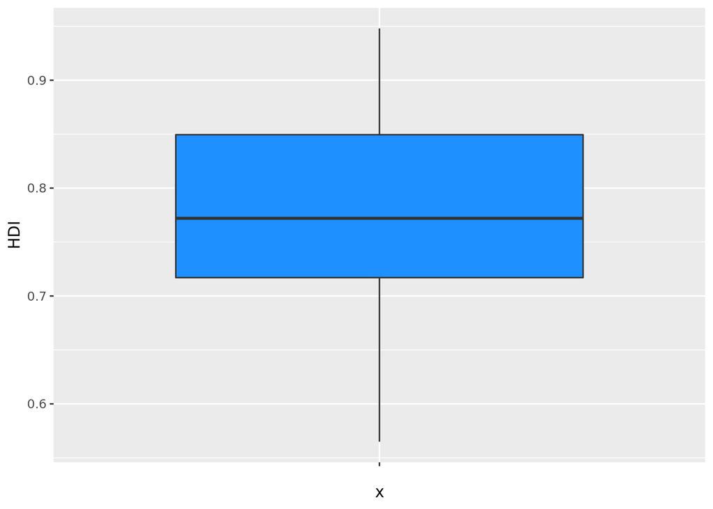

```r
g + geom_boxplot(aes(x="", y=HDI), fill="dodgerblue")
```

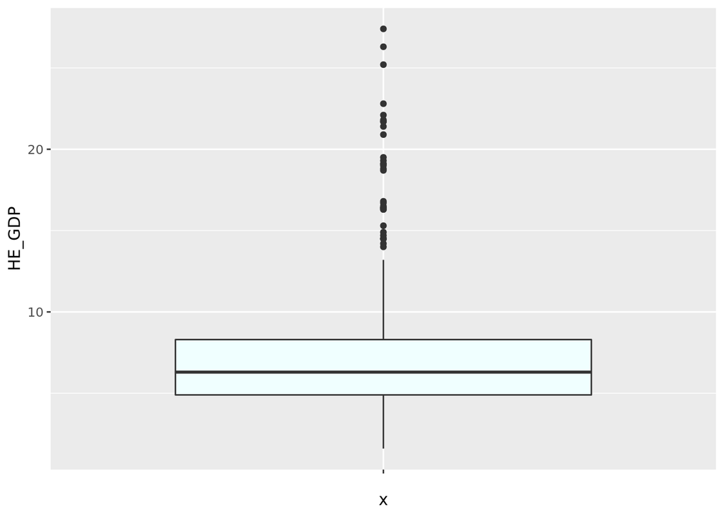

```r
g + geom_boxplot(aes(x="", y=HE_GDP), fill="azure")
```

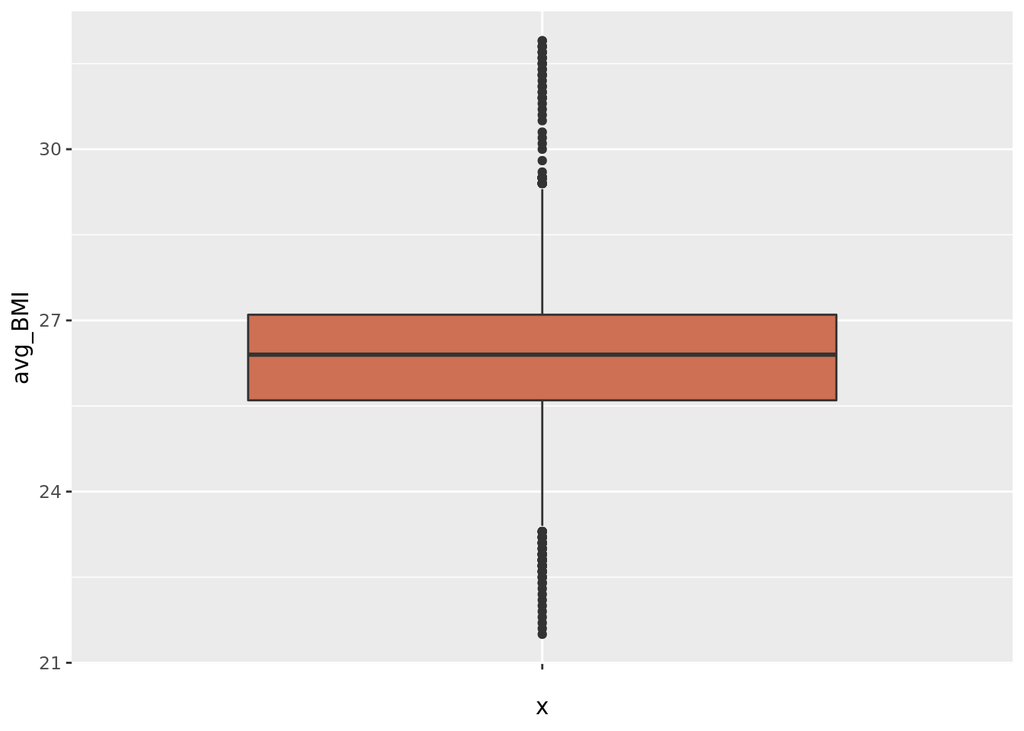

```r
g + geom_boxplot(aes(x="", y=avg_BMI), fill="salmon3")
```

```r
# # animated scatter by year, source = http://r-statistics.co/Top50-Ggplot2-Visualizations-MasterList-R-Code.html#Animated%20Bubble%20Plot

# library(gganimate)
# library(gapminder)
# theme_set(theme_bw())  # pre-set the bw theme.
#

# g2 <- ggplot(gapminder, aes(HE_GDP, LEB, size = HDI, frame = Year)) +
#   geom_point() +
#   geom_smooth(aes(group = Year),
#               method = "lm",
#               show.legend = FALSE) +
#   facet_wrap(~Region, scales = "free") +
#   scale_x_log10()  # convert to log scale
#
# gganimate(g2, interval=0.2)
```

## Set up for linear models

Here we partition the data to a 80%/20% split and create two dataframes for training and validation.

```r
#Partition
set.seed(267)
test_pct <- 0.20
num_test_recs <- as.integer(test_pct * nrow(pp3))

test_recs <- sample(nrow(pp3), num_test_recs)

pp_train <- pp3[-test_recs,]
pp_test <- pp3[test_recs,]
```

To begin our regression modeling, we chose to do a null and full model. Including both a null and full model would highlight what the data would look like with the full set and classifiing variables removed, specifcally country, region, and the year, as these were irrelevant to our planned predictions. These models were split into the training set, shown here, and the test data, shown as predNull and predFull below.

```r
#Test1
nullModel <- lm(LEB ~ 1, data = pp_train)
fullModel <- lm(LEB ~ ., data = pp_train)

summary(nullModel)
```

```
##
## Call:
## lm(formula = LEB ~ 1, data = pp_train)
##
## Residuals:
##     Min      1Q  Median      3Q     Max
## -5.9708 -0.5255 -0.0265  0.7382  1.9694
##
## Coefficients:
##               Estimate Std. Error t value Pr(>|t|)
## (Intercept) -0.0003931  0.0259363  -0.015    0.988
##
## Residual standard error: 0.9937 on 1467 degrees of freedom
```

```r
summary(fullModel)
```

```
##
## Call:
## lm(formula = LEB ~ ., data = pp_train)
##
## Residuals:
##      Min       1Q   Median       3Q      Max
## -0.67441 -0.04237 -0.00185  0.04022  0.61774
##
## Coefficients:
##              Estimate Std. Error t value Pr(>|t|)
## (Intercept) -0.083328   0.010088  -8.260 3.25e-16 ***
## HDI          0.057074   0.007580   7.529 8.91e-14 ***
## NMR          0.031719   0.013592   2.334  0.01975 *
## IMR          0.008883   0.031448   0.282  0.77763
## U5MR        -0.226965   0.027684  -8.198 5.30e-16 ***
## X5_14MR     -0.036580   0.006355  -5.756 1.05e-08 ***
## AMR         -0.455042   0.005141 -88.505  < 2e-16 ***
## LE_60        0.406149   0.005538  73.334  < 2e-16 ***
## UA          -0.007559   0.006091  -1.241  0.21483
## OA          -0.041966   0.008178  -5.132 3.26e-07 ***
## OBA         -0.003368   0.008881  -0.379  0.70456
## avg_BMI      0.038567   0.006086   6.337 3.12e-10 ***
## ABS         -0.009954   0.004761  -2.091  0.03670 *
## HE_GDP       0.012638   0.001449   8.723  < 2e-16 ***
## HE_CAP      -0.014816   0.005433  -2.727  0.00647 **
## ---
## Signif. codes:  0 '***' 0.001 '**' 0.01 '*' 0.05 '.' 0.1 ' ' 1
##
## Residual standard error: 0.1096 on 1453 degrees of freedom
## Multiple R-squared:  0.988,  Adjusted R-squared:  0.9878
## F-statistic:  8512 on 14 and 1453 DF,  p-value: < 2.2e-16
```

## Model Predictions

We then calculated the mean average error (MAE) for the train and test set for both the null and full models. MAE was our metric for evaluating the effectiveness of our prediction models.

```r
#Prediction
predNull <- predict(nullModel, newdata = pp_test)
predFull <- predict(fullModel, newdata = pp_test)

#MAE of fit
maeNull_fit <- MAE(predNull, pp_train$LEB)
maeNull_fit
```

```
## [1] 0.7495744
```

```r
maeFull_fit <- MAE(predFull, pp_train$LEB)
maeFull_fit
```

```
## [1] 1.088817
```

```r
#MAE of test
maeNull <- MAE(predNull, pp_test$LEB)
maeNull
```

```
## [1] 0.778726
```

```r
maeFull <- MAE(predFull, pp_test$LEB)
maeFull
```

```
## [1] 0.06692964
```

Then we created several other models, exchanging individual variables to see which gave us the most accurate predictions. Model 2 included variables that had a low correlation to life expectancy at birth. Model 3 included variables that had a slightly higher, but still relatively small correlation to life expectancy at birth. Model 4 included the variables that had the smallest correlation values to life expectancy at birth.

We then created fit models for the MAEs for the models mentioned above for both the test and training sets.

```r
#Additional Models
Model2 <- lm(LEB ~ OA + OBA + HE_GDP, data = pp_train)
Model3 <- lm(LEB ~ avg_BMI + X5_14MR + HE_CAP, data = pp_train)
Model4 <- lm(LEB ~ OBA + avg_BMI, data = pp_train)

summary(Model2)
```

```
##
## Call:
## lm(formula = LEB ~ OA + OBA + HE_GDP, data = pp_train)
##
## Residuals:
##     Min      1Q  Median      3Q     Max
## -5.4791 -0.4698  0.0530  0.5416  2.7415
##
## Coefficients:
##              Estimate Std. Error t value Pr(>|t|)
## (Intercept) -0.944875   0.064718 -14.600  < 2e-16 ***
## OA           0.448334   0.049971   8.972  < 2e-16 ***
## OBA         -0.380134   0.049249  -7.719 2.16e-14 ***
## HE_GDP       0.141795   0.009099  15.584  < 2e-16 ***
## ---
## Signif. codes:  0 '***' 0.001 '**' 0.01 '*' 0.05 '.' 0.1 ' ' 1
##
## Residual standard error: 0.8751 on 1464 degrees of freedom
## Multiple R-squared:  0.226,  Adjusted R-squared:  0.2244
## F-statistic: 142.5 on 3 and 1464 DF,  p-value: < 2.2e-16
```

```r
summary(Model3)
```

```
##
## Call:
## lm(formula = LEB ~ avg_BMI + X5_14MR + HE_CAP, data = pp_train)
##
## Residuals:
##     Min      1Q  Median      3Q     Max
## -3.9274 -0.2998  0.0199  0.3852  1.9329
##
## Coefficients:
##              Estimate Std. Error t value Pr(>|t|)
## (Intercept) -0.002638   0.015999  -0.165   0.8690
## avg_BMI      0.038575   0.016253   2.373   0.0178 *
## X5_14MR     -0.521149   0.018653 -27.939   <2e-16 ***
## HE_CAP       0.408989   0.018003  22.717   <2e-16 ***
## ---
## Signif. codes:  0 '***' 0.001 '**' 0.01 '*' 0.05 '.' 0.1 ' ' 1
##
## Residual standard error: 0.6129 on 1464 degrees of freedom
## Multiple R-squared:  0.6203, Adjusted R-squared:  0.6196
## F-statistic: 797.3 on 3 and 1464 DF,  p-value: < 2.2e-16
```

```r
summary(Model4)
```

```
##
## Call:
## lm(formula = LEB ~ OBA + avg_BMI, data = pp_train)
##
## Residuals:
##     Min      1Q  Median      3Q     Max
## -5.7593 -0.5353 -0.0379  0.7477  2.3099
##
## Coefficients:
##              Estimate Std. Error t value Pr(>|t|)
## (Intercept) 0.0006175  0.0256147   0.024  0.98077
## OBA         0.1346124  0.0488929   2.753  0.00597 **
## avg_BMI     0.0307918  0.0487861   0.631  0.52804
## ---
## Signif. codes:  0 '***' 0.001 '**' 0.01 '*' 0.05 '.' 0.1 ' ' 1
##
## Residual standard error: 0.9814 on 1465 degrees of freedom
## Multiple R-squared:  0.02607,    Adjusted R-squared:  0.02474
## F-statistic: 19.61 on 2 and 1465 DF,  p-value: 3.94e-09
```

```r
#Prediction
predModel2 <- predict(Model2, newdata = pp_test)
predModel3 <- predict(Model3, newdata = pp_test)
predModel4 <- predict(Model4, newdata = pp_test)

#MAE of fit
maeModel2_fit <- MAE(predModel2, pp_train$LEB)
maeModel2_fit
```

```
## [1] 0.8556094
```

```r
maeModel3_fit <- MAE(predModel3, pp_train$LEB)
maeModel3_fit
```

```
## [1] 0.9911452
```

```r
maeModel4_fit <- MAE(predModel4, pp_train$LEB)
maeModel4_fit
```

```
## [1] 0.7638287
```

```r
#MAE of test
maeModel2 <- MAE(predModel2, pp_test$LEB)
maeModel2
```

```
## [1] 0.6615628
```

```r
maeModel3 <- MAE(predModel3, pp_test$LEB)
maeModel3
```

```
## [1] 0.4637544
```

```r
maeModel4 <- MAE(predModel4, pp_test$LEB)
maeModel4
```

```
## [1] 0.7680449
```

We then compared the models created above to determine which model provided the most accurate prediction of life expectancy at birth.

```r
#Compare Models
maeNull_fit
```

```
## [1] 0.7495744
```

```r
maeNull
```

```
## [1] 0.778726
```

```r
maeFull_fit
```

```
## [1] 1.088817
```

```r
maeFull
```

```
## [1] 0.06692964
```

```r
maeModel2_fit
```

```
## [1] 0.8556094
```

```r
maeModel2
```

```
## [1] 0.6615628
```

```r
maeModel3_fit
```

```
## [1] 0.9911452
```

```r
maeModel3
```

```
## [1] 0.4637544
```

```r
maeModel4_fit
```

```
## [1] 0.7638287
```

```r
maeModel4
```

```
## [1] 0.7680449
```

## Analysis conclusions

When comparing the models, the full model, as well as models 2 and 3 have less error when fit to the test set than fitting to the training. This could be possible because of a few reasons. Being that our dataset is relatively small (~1800 total observations), a random 80/20 split could result in a test set that is very much like our training set statistically, but has less “noise.”

To dive deeper into this issue, we are going to experiment with cross validation in the next code chunk.

## Exploring cross validation

To begin our cross validation efforts, we referenced a video on YouTube from The Data Science Show titled “Cross Validation using caret package in R”. Source: https://www.youtube.com/watch?=Zd9GRoQjKvo, along with RPubs Source: www.rpubs.com/StrategyExplorer/232768

```r
# Partition the data on LEB
set.seed(1059)
partitionRule <- createDataPartition(pp3$LEB, p = 0.7, list = F)
# Create cross validation sets
cvTrain <- pp3[partitionRule,]
cvTest <- pp3[-partitionRule,]
```

Moving on to cross validation model testing.

```r
# Fix models to cv'd sets
# Model2 <- lm(LEB ~ OA + OBA + HE_GDP, data = pp_train)
# Model3 <- lm(LEB ~ avg_BMI + X5_14MR + HE_CAP, data = pp_train)
# Model4 <- lm(LEB ~ OBA + avg_BMI, data = pp_train)

cvModel2 <- train(LEB ~ OA + OBA + HE_GDP, data = cvTrain, trControl = trainControl(method = "cv", number = 10, verboseIter = TRUE))
cvModel3 <- train(LEB ~ avg_BMI + X5_14MR + HE_CAP, data = cvTrain, trControl = trainControl(method = "cv", number = 10, verboseIter = TRUE))
cvModel4 <- train(LEB ~ OBA + avg_BMI, data = cvTrain, trControl = trainControl(method = "cv", number = 10, verboseIter = TRUE))
```

Printing our models to see how they did.

```r
print(cvModel2)
```

```
## Random Forest
##
## 1287 samples
##    3 predictor
##
## No pre-processing
## Resampling: Cross-Validated (10 fold)
## Summary of sample sizes: 1158, 1157, 1158, 1159, 1159, 1159, ...
## Resampling results across tuning parameters:
##
##   mtry  RMSE       Rsquared   MAE
##   2     0.6123464  0.6150860  0.4558494
##   3     0.6164716  0.6090505  0.4538779
##
## RMSE was used to select the optimal model using the smallest value.
## The final value used for the model was mtry = 2.
```

```r
print(cvModel3)
```

```
## Random Forest
##
## 1287 samples
##    3 predictor
##
## No pre-processing
## Resampling: Cross-Validated (10 fold)
## Summary of sample sizes: 1158, 1158, 1157, 1158, 1158, 1159, ...
## Resampling results across tuning parameters:
##
##   mtry  RMSE       Rsquared   MAE
##   2     0.4186902  0.8115783  0.2922288
##   3     0.4242610  0.8059393  0.2940042
##
## RMSE was used to select the optimal model using the smallest value.
## The final value used for the model was mtry = 2.
```

```r
print(cvModel4)
```

```
## Random Forest
##
## 1287 samples
##    2 predictor
##
## No pre-processing
## Resampling: Cross-Validated (10 fold)
## Summary of sample sizes: 1159, 1159, 1158, 1158, 1158, 1159, ...
## Resampling results:
##
##   RMSE       Rsquared   MAE
##   0.8428995  0.2921496  0.6675072
##
## Tuning parameter 'mtry' was held constant at a value of 2
```

## Cross validation analysis conclusions

Based on our k-fold cross validation results, we would now pick Model 3 as our best model for prediction.

Model 3 included the variables “avg_BMI + X5_14MR + HE_CAP” (average BMI, mortality rate at age 5-14, and health expenditure per capita). With the best results in Root Mean Squared Error, Rsquared, and MAE, we would use Model 3 to predict life expectancy at birth.